« Retour au Portfolio

# Exos3_CrossValidation

#### Cours à moi-même:

- **MSE/RMSE/MAE** sont des **Métriques de performances**, elles sont efficace si elles sont les plus petite possible elles permettent de comparer:
  - Des modéles avec des dimenssion différentes
  - Des modéles différent (classification / Regression...)
- On réduit les dimenssion aprés avoir tester le tout avant on se sert de la corrélation et la heatmap
- **les paramétres :** sont trouver automatiquement par le modéle et par le train(entreinement)
- **les Hyerparamétres :** c'est ce qui est configuerer manuellement (ce qu'on choisit)

#### Remédiation

##### Cross Validation

[figure not shown]

C'est faire plusieurs métrique sur un même jeux de donnée Le But est d'avoir un Modéle solide/robuste, cad avoir des Métrique proche en fonction des jeux de donnée générer. Pour cela on va comparer la moyenne (marge d'erreur de 5-10% en fonction des domaines) à la moyenne. Bonne pratique: on refait sur le data set global

Le crossvalidation et obligatoire pour montrer que le modéle et solide. Le Risque est le surapprentissage:

##### Régularisation pour éviter le surapprentissage

https://www.ibm.com/fr-fr/think/topics/regularization

[figure not shown]

La Régulariation permet de lissé, on ajoute une contrainte avec lamda ⁁

Les valeur de ⁁ sont les hyperparamétre sur lequel on va travailler

2 méthodes utiliser

**Lasso** : capable de mettre béta β = 0 c'est associé à + ⁁ ∑ |β|

**Ridge** : met β trés proche de 0 c'est associé à + ⁁ ∑ |β|^2

### Validation croisée K-fold

#### Tâche 1

```python
import pandas as pd
import numpy as np
```

```python
import numpy as np
from sklearn.model_selection import KFold
X = np.array([['A', 'B'], ['C', 'D'], ['E', 'F'], ['G', 'H']])
y = np.array([1, 2, 3, 4])
kf = KFold(n_splits=3) # ici on choisit le nombre de plis (ou splits) que l'on va faire
kf.get_n_splits(X)

for train_index, valid_index in kf.split(X): # kf.split(X) est un itérable qui nous donne les indices des données dans chaque pli
    X_train, X_valid = X[train_index], X[valid_index]
    y_train, y_valid = y[train_index], y[valid_index]
```

```python
auto = pd.read_csv('./data/Auto.csv')
auto = auto[auto.horsepower != '?']
auto['horsepower'] = auto.horsepower.astype(int)
auto.reset_index(inplace=True, drop=True)
auto.head()
```

|  | mpg | cylinders | displacement | horsepower | weight | acceleration | year | origin | name |
| --- | --- | --- | --- | --- | --- | --- | --- | --- | --- |
| 0 | 18.0 | 8 | 307.0 | 130 | 3504 | 12.0 | 70 | 1 | chevrolet chevelle malibu |
| 1 | 15.0 | 8 | 350.0 | 165 | 3693 | 11.5 | 70 | 1 | buick skylark 320 |
| 2 | 18.0 | 8 | 318.0 | 150 | 3436 | 11.0 | 70 | 1 | plymouth satellite |
| 3 | 16.0 | 8 | 304.0 | 150 | 3433 | 12.0 | 70 | 1 | amc rebel sst |
| 4 | 17.0 | 8 | 302.0 | 140 | 3449 | 10.5 | 70 | 1 | ford torino |

```python
mpg = auto.pop('mpg') # mpg sera notre cible et nous le supprimons donc dans un tableau séparé
```

#### Tâche 2

1. - essayez d'ajouter des instructions d'impression pour la taille des trames de données dans chaque division
2. - essayez d'augmenter le nombre de fractionnements et réexécutez votre code
3. - utilisez le code ci-dessous pour imprimer un nom de voiture contenu dans l'ensemble de données de train et de validation, pour chaque fractionnement

```python
# 1. Tâche 2.1 : Imprimer la taille des trames de données dans chaque division

    # (Nous affichons ici la taille du DataFrame/Série)
print(f"Tâche 2.1 - Taille de X_train : {X_train.shape[0]} lignes | X_valid : {X_valid.shape[0]} lignes")
print(f"Taille de y_train : {y_train.shape[0]} lignes | y_valid : {y_valid.shape[0]} lignes")
```

```
Tâche 2.1 - Taille de X_train : 3 lignes | X_valid : 1 lignes
Taille de y_train : 3 lignes | y_valid : 1 lignes
```

```python
# 2. Tâche 2.2 : Modifier le code pour utiliser KFold avec les paramétres appropriés

kf = KFold(n_splits=5, shuffle=True, random_state=42) # Nous utilisons KFold avec les paramètres :
        # 1. shuffle=True pour mélanger les données avant de les diviser en plis
        # 2. n_splits=5 pour faire 5 plis on rép à la tâches 2.2 pour augmenter le nb de fractionnements
        # 3. random_state=42 pour que le mélange soit reproductible
kf.get_n_splits(auto)

print(kf)
```

```
KFold(n_splits=5, random_state=42, shuffle=True)
```

```python
#Code 1
#3. Tâche 2.3 : Imprimer un nom de voiture (ADAPTATION: Index d'échantillon)
    # Nous imprimons le premier ID d'échantillon (index) de chaque ensemble

split_counter = 1
for train_index, valid_index in kf.split(auto): # kf.split(X) is an iterable which gives us the indices of the data in each fold
    print('-'*60)
    print('This is split no: {}'.format(split_counter))
    split_counter += 1
    X_train, X_valid = auto.iloc[train_index], auto.iloc[valid_index] # must use .iloc because its a dataframe this time
    y_train, y_valid = mpg[train_index], mpg[valid_index]

    # VOTRE CODE ICI (Tâche 2.3)
    # Justification: X_train et X_valid sont des DataFrames.
    # La colonne 'name' contient les noms. .iloc[0] prend la première ligne du sous-DataFrame.

    # Imprimer le nom de la première voiture dans l'ensemble d'entraînement
    train_car_name = X_train['name'].iloc[0]
    print(f'Train car name here: {train_car_name}')

    # Imprimer le nom de la première voiture dans l'ensemble de validation
    valid_car_name = X_valid['name'].iloc[0]
    print(f'Validation car name here: {valid_car_name}')
```

```
------------------------------------------------------------
This is split no: 1
Train car name here: buick skylark 320
Validation car name here: chevrolet chevelle malibu
------------------------------------------------------------
This is split no: 2
Train car name here: chevrolet chevelle malibu
Validation car name here: chevrolet impala
------------------------------------------------------------
This is split no: 3
Train car name here: chevrolet chevelle malibu
Validation car name here: plymouth satellite
------------------------------------------------------------
This is split no: 4
Train car name here: chevrolet chevelle malibu
Validation car name here: ford torino
------------------------------------------------------------
This is split no: 5
Train car name here: chevrolet chevelle malibu
Validation car name here: buick skylark 320
```

```python
auto = auto.drop('name', axis=1, errors='ignore') # nous n'avons pas besoin des noms de voitures, alors supprimez-les pour l'instant.
```

Nous pouvons utiliser la même boucle pour ajuster et évaluer notre modèle de régression linéaire sur chaque répartition entraînement/validation :

```python
from sklearn.linear_model import LinearRegression
from sklearn.metrics import mean_squared_error


split_counter = 1
mse_scores = [] # create empty list to append mse scores for each split
kf = KFold(n_splits=5)
kf.get_n_splits(auto)

for train_index, valid_index in kf.split(auto): # kf.split(X) is an iterable which gives us the indices of the data in each fold
    print('-'*60)
    print('This is split no: {}'.format(split_counter))
    print('Model results')
    split_counter += 1
    X_train, X_valid = auto.iloc[train_index], auto.iloc[valid_index] # must use .iloc because its a dataframe this time
    y_train, y_valid = mpg[train_index], mpg[valid_index]


    #### fit polynomial to train data in this split
    lin_reg = LinearRegression()
    lin_reg.fit(X_train, y_train)

    #### eval & print MSE training results in this split
    mpg_train_pred = lin_reg.predict(X_train)
    mse_train = mean_squared_error(y_train, mpg_train_pred)
    print('training MSE: {0}'.format(mse_train))

    #### do the same for validation split
    mpg_valid_pred = lin_reg.predict(X_valid)
    mse_valid = mean_squared_error(y_valid, mpg_valid_pred)
    print('validation MSE: {0}'.format(mse_valid))

    mse_scores.append(mse_valid) # assign validation MSE score to list
```

```
------------------------------------------------------------
This is split no: 1
Model results
training MSE: 11.284070590566005
validation MSE: 14.974307651304157
------------------------------------------------------------
This is split no: 2
Model results
training MSE: 11.155158050598773
validation MSE: 10.905952427081155
------------------------------------------------------------
This is split no: 3
Model results
training MSE: 12.16010513687152
validation MSE: 5.9917086101081605
------------------------------------------------------------
This is split no: 4
Model results
training MSE: 9.921674145405689
validation MSE: 15.587544657621601
------------------------------------------------------------
This is split no: 5
Model results
training MSE: 7.977511689294959
validation MSE: 27.844743081984205
```

Lors de l'utilisation de la validation croisée k-fold, nous pouvons analyser le résultat de validation MSE pour chaque division afin d'évaluer la performance globale.

```python
mse_scores  = np.array(mse_scores)
print('VALIDATION SET MSE SCORES')
print('mean MSE:', mse_scores.mean())
print('std MSE:', mse_scores.std())
```

```
VALIDATION SET MSE SCORES
mean MSE: 15.060851285619856
std MSE: 7.255691814890935
```

#### La validation croisée en pratique dans sklearn

```python
#Code 5           <========== ICI le CODE 5
from sklearn.model_selection import cross_val_score
lin_reg = LinearRegression()

cv_scores = cross_val_score(lin_reg, auto, mpg, cv = 5, scoring='neg_mean_squared_error')

print('mean MSE:',np.mean(-cv_scores))
print('std MSE:',np.std(-cv_scores))
```

```
mean MSE: 15.060851285619856
std MSE: 7.255691814890935
```

```python
cv_scores # est-ce le  predict ?
```

```
array([-14.97430765, -10.90595243,  -5.99170861, -15.58754466,
       -27.84474308])
```

**Tâche 3 :**

3. 1. - Assurez-vous de bien comprendre le résultat du cross_val_score ci-dessus (c'est-à-dire qu'est-ce que cv_scores ?)

##### Réponse 3.1:

**cv_scores est un tableau NumPy** contenant les 5 scores d'évaluation (un score par pli, puisque cv=5) du modèle de régression linéaire appliqué à l'ensemble de validation de chaque pli.

Puisque le paramètre d'évaluation utilisé dans le code 5 est

**scoring='neg_mean_squared_error',** les 5 valeurs dans **cv_scores** représentent le MSE (Erreur Quadratique Moyenne) négatif du modèle sur chaque ensemble de validation.

3. 2. - Pourquoi le score est-il défini comme un MSE négatif ? Faites des recherches

##### Réponse 3.2:

https://datascientest.com/metriques-en-machine-learning

Le score est défini comme un MSE négatif **(neg_mean_squared_error #code 5)**

pour une question de convention dans Scikit-learn : Convention :Les fonctions de scoring de Scikit-learn sont conçues pour être maximisées (plus la valeur est élevée, meilleur est le modèle).

*Le meilleure mean_squared_error est le plus cad le plus proche de 0(en négatif)*

Problème : Le MSE est une mesure d'erreur que l'on cherche à minimiser (plus le MSE est petit, meilleur est le modèle). Solution : En prenant l'opposé (le négatif) du MSE, on transforme la minimisation en une maximisation.

L'utilisation du négatif permet d'intégrer toutes les métriques dans un cadre où l'objectif est toujours d'atteindre la valeur la plus élevée.

3. 3. - Enquêtez sur ce que fait la fonction `cross_val_predict`.

##### Réponse :

https://scikit-learn.org/stable/modules/generated/sklearn.model_selection.cross_val_predict.html

**La fonction cross_val_predict** effectue une validation croisée complète (par exemple, 5 fois avec cv=5). Cependant, au lieu de retourner les scores de performance de chaque pli *(comme le fait cross_val_score)*,

**elle retourne les prédictions pour chaque échantillon du jeu de données d'origine (auto).**

Processus : Chaque échantillon est prédit une seule fois par un modèle qui n'a jamais vu cet échantillon pendant sa phase d'entraînement.

3. 4. - Importez et implémentez `cross_val_predict` sur les mêmes données que ci-dessus.

```python
from sklearn.model_selection import cross_val_predict
from sklearn.linear_model import LinearRegression
from sklearn.metrics import mean_squared_error
import numpy as np

lin_reg = LinearRegression()

# Implémentation de cross_val_predict

mpg_pred_cv = cross_val_predict(lin_reg, auto, mpg, cv=5)

# lin_reg : modéle de régression linéaire (on peut utiliser un autre modèle)
# auto : données d'entrée
# mpg : variable cible
# cv=5 : nombre de plis

print(f"La prédiction validée croisée a été générée : 'mpg_pred_cv'.")
print(f"Taille de la prédiction : {len(mpg_pred_cv)} (égale à la taille de 'mpg').")
print(f"Les 5 premières vraies valeurs (mpg) : {mpg.head().to_numpy()}")
print(f"Les 5 premières prédictions (mpg_pred_cv) : {mpg_pred_cv[:5]}")
```

```
La prédiction validée croisée a été générée : 'mpg_pred_cv'.
Taille de la prédiction : 392 (égale à la taille de 'mpg').
Les 5 premières vraies valeurs (mpg) : [18. 15. 18. 16. 17.]
Les 5 premières prédictions (mpg_pred_cv) : [13.18110394 11.64748588 13.09596676 12.93021809 12.98800698]
```

```python
# Affiche le cross_val_predict (décommenté)
# mpg_pred_cv
```

3. 5. - Quelles sont les sorties de cette fonction ?

##### Réponse :

La sortie de cross_val_predict (mpg_pred_cv) est un **tableau NumPy 1D** qui contient la prédiction du modèle pour chaque échantillon du jeu de données d'entrée (auto). Sa taille est égale à celle de la variable cible mpg.

3. 6. - Pouvez-vous les utiliser pour évaluer les résultats de votre validation croisée ?

##### Réponse : OUI.

https://www.datacamp.com/fr/tutorial/k-fold-cross-validation

L'ensemble des prédictions (mpg_pred_cv) permet de calculer une métrique d'erreur globale (comme le MSE ou le RMSE) sur la totalité des données.

C'est un moyen très fiable et synthétique d'évaluer la performance moyenne du modèle, car chaque prédiction a été faite par un modèle qui n'était pas entraîné sur l'échantillon correspondant.

```python
# Utilisation de la prédiction pour évaluer le MSE global
mse_cv_predict = mean_squared_error(mpg, mpg_pred_cv)

print(f"MSE global calculé à partir de cross_val_predict : {mse_cv_predict:.4f}")
# Ce score devrait être très proche de 'mean MSE' calculé par cross_val_score (code 5
```

```
MSE global calculé à partir de cross_val_predict : 15.0500
```

```python
# Vérification de la proximité des scores
print(f"Différence absolue entre MSE global et mean MSE de cross_val_score : {abs(mse_cv_predict - np.mean(-cv_scores)):.6f}")
# cf code 5 mean MSE
```

```
Différence absolue entre MSE global et mean MSE de cross_val_score : 0.010820
```

3. 7. - Les scores de validation croisée vous donnent-ils l'assurance que ce modèle fournit une prédiction utile ?

##### Réponse :NON.

(il n'y a pas de surapprentissage ou de sous-apprentissage dépendant de la partition).

**Utilité (NON) :** L'utilité est une question de domaine et de seuil d'acceptabilité de l'erreur.

*Le MSE moyen (dans le code 5 : $\approx 15.0$) est une erreur quadratique.*

*Le RMSE (erreur moyenne en unité réelle) est $\sqrt{15.1} \approx 3.87racine carrée de 15$ MPG.*

Si une erreur de $\pm 3.87$ MPG est trop grande pour les besoins de l'entreprise (par exemple, si la plage de MPG est petite), alors le modèle n'est pas utile, même s'il est robuste.

## Exercice 1 : validation croisée des vins

[figure not shown]

>

Vous devez prédire la teneur en alcool de divers vins en fonction de leurs autres attributs.

1. - Divisez les données en ensembles de données d'entraînement et de test (assurez-vous d'utiliser l'option : `random_state = 28`).

```python
# Charge les données
wine = pd.read_csv('./data/wine.csv')
```

```python
# 1 : Diviser les données avec random_state = 28
from sklearn.model_selection import train_test_split

# DÉFINITION DE LA CIBLE (y) et des CARACTÉRISTIQUES (X)
y = wine.pop('Alcohol') # Tâche : 'Alcohol' est la cible (y)
X = wine                # X contient toutes les autres caractéristiques

X_train, X_test, y_train, y_test = train_test_split(X, y, random_state=28)
print('Train set:', X_train.shape)
print('Test set:', X_test.shape)
```

```
Train set: (133, 13)
Test set: (45, 13)
```

2. - a/Effectuez une régression linéaire en utilisant la validation croisée k-fold (assurez-vous d'utiliser 5 plis).
   - b/Renvoie les erreurs MSE de validation croisée. Renvoyez la moyenne et les écarts types de ceux-ci.

```python
# 2.a
# Initialisation du modèle pour les étapes suivantes
lin_reg = LinearRegression()

# Régression Linéaire avec K-Fold (cv=5)
# Nous utilisons cross_val_score sur l'ensemble d'entraînement (X_train, y_train)

# Exécuter la validation croisée
cross_val_scores = cross_val_score(lin_reg, X_train, y_train, cv=5, scoring='neg_mean_squared_error')

# 2.b
# Affichage des résultats MSE de la valadition croisée
mean_mse_cv = np.mean(-cross_val_scores)
std_mse_cv = np.std(-cross_val_scores)

print('mean MSE:', mean_mse_cv)
print('std MSE:', std_mse_cv)
print('les erreurs négatives par pli:', cross_val_scores)
```

```
mean MSE: 0.4771472419568702
std MSE: 0.1372676452471343
les erreurs négatives par pli: [-0.26271057 -0.38623508 -0.55062417 -0.65506213 -0.53110424]
```

3. - Évaluer les performances du modèle sur l'ensemble de test.

```python
# Entraînement du modèle sur l'ensemble d'entraînement complet
lin_reg.fit(X_train, y_train)

# Prédiction sur l'ensemble de test
y_test_pred = lin_reg.predict(X_test)

# Calcul de l'erreur MSE sur l'ensemble de test
mse_test = mean_squared_error(y_test, y_test_pred)

print("Évaluation sur l'Ensemble de Test :")
print(f"MSE sur l'Ensemble de Test : {mse_test:.4f}")
```

```
Évaluation sur l'Ensemble de Test :
MSE sur l'Ensemble de Test : 0.4772
```

4. - Comparez l'erreur de validation croisée et l'erreur de test (MSE). Que trouvez-vous ?

```python
# Tâche 1.4 : Comparer l'erreur de validation croisée et l'erreur de test (MSE).
print("Comparaison des Erreurs :")
print(f"MSE Moyen de Validation Croisée : {mean_mse_cv:.4f}")
print(f"MSE sur l'Ensemble de Test : {mse_test:.4f}")
```

```
Comparaison des Erreurs :
MSE Moyen de Validation Croisée : 0.4771
MSE sur l'Ensemble de Test : 0.4772
```

5. - Essayez de supprimer l'option random_state. Qu’arrive-t-il à vos résultats ? Expliquez pourquoi.

**Résultats :**

La suppression de random_state dans train_test_split entraînerait la modification des valeurs du MSE Moyen CV et du MSE de Test à chaque nouvelle exécution du code.

**Explication :**

L'option random_state sert à fixer la séquence aléatoire utilisée pour mélanger et diviser les données. Sans elle, le processus de shuffling utilise un facteur variable (comme l'heure système), créant des ensembles X_train, X_test, etc., différents à chaque fois.

**Pour garantir la reproductibilité de nos résultats et pouvoir valider une expérience de manière fiable, il est impératif de toujours spécifier le random_state.**

## Régularisation

#### Régression lasso dans sklearn

Dans cet exemple, nous visons à prédire la cote de crédit de clients individuels. Pour entraîner et prédire à l'aide d'une régression Lasso, nous suivons à peu près la même procédure que celle que nous avons vue précédemment dans « scikit-learn ».

```python
credit = pd.read_csv('./data/credit_modified.csv')
rating = credit.pop('Rating')
credit.head()
```

|  | Income | Limit | Cards | Age | Education | Gender | Student | Married | Balance | African American | Asian | Caucasian |
| --- | --- | --- | --- | --- | --- | --- | --- | --- | --- | --- | --- | --- |
| 0 | 14.891 | 3606 | 2 | 34 | 11 | 0 | 0 | 1 | 333 | 0 | 0 | 1 |
| 1 | 106.025 | 6645 | 3 | 82 | 15 | 1 | 1 | 1 | 903 | 0 | 1 | 0 |
| 2 | 104.593 | 7075 | 4 | 71 | 11 | 0 | 0 | 0 | 580 | 0 | 1 | 0 |
| 3 | 148.924 | 9504 | 3 | 36 | 11 | 1 | 0 | 0 | 964 | 0 | 1 | 0 |
| 4 | 55.882 | 4897 | 2 | 68 | 16 | 0 | 0 | 1 | 331 | 0 | 0 | 1 |

```python
#### splitting train and test set
from sklearn.model_selection import train_test_split
X_train, X_test, y_train, y_test = train_test_split(credit, rating, random_state = 91)
```

```python
from sklearn.linear_model import Lasso

lasso = Lasso(alpha = 10)
cv_scores = cross_val_score(lasso, X_train, y_train, cv = 5, scoring='neg_mean_squared_error')
print('mean MSE:',np.mean(-cv_scores))
print('std MSE:',np.std(-cv_scores))
```

```
mean MSE: 148.36580248151395
std MSE: 22.577610846122532
```

#### Utiliser Lasso avec la recherche par grille

Sûr, « scikit-learn » a une fonction qui automatise cela pour vous. En utilisant `GridSearchCV`, nous transmettons un dictionnaire de valeurs de paramètres que nous souhaitons étudier. La fonction s'adaptera à chaque modèle que nous avons répertorié et calculera l'erreur de validation croisée de chacun.

```python
#Code 4

from sklearn.model_selection import GridSearchCV
lasso = Lasso(max_iter=10000)

param_grid = [
 {'alpha': [0.001, 0.01, 0.1, 1, 3, 10, 100, 1000]}
 ]

grid_search = GridSearchCV(lasso, param_grid, cv=10, scoring='neg_mean_squared_error')
grid_search.fit(X_train, y_train)

grid_results = pd.DataFrame(grid_search.cv_results_)

grid_results.head()
```

|  | mean_fit_time | std_fit_time | mean_score_time | std_score_time | param_alpha | params | split0_test_score | split1_test_score | split2_test_score | split3_test_score | split4_test_score | split5_test_score | split6_test_score | split7_test_score | split8_test_score | split9_test_score | mean_test_score | std_test_score | rank_test_score |
| --- | --- | --- | --- | --- | --- | --- | --- | --- | --- | --- | --- | --- | --- | --- | --- | --- | --- | --- | --- |
| 0 | 0.005991 | 0.000220 | 0.001687 | 0.000055 | 0.001 | {'alpha': 0.001} | -134.693531 | -105.857049 | -101.376944 | -87.569097 | -78.913304 | -76.137420 | -109.786540 | -103.885686 | -106.104721 | -113.455931 | -101.778022 | 16.450021 | 3 |
| 1 | 0.005396 | 0.000296 | 0.001692 | 0.000136 | 0.010 | {'alpha': 0.01} | -134.553201 | -105.948212 | -101.096381 | -87.881139 | -78.937345 | -76.585584 | -109.682491 | -103.106018 | -106.112572 | -113.688788 | -101.759173 | 16.329243 | 2 |
| 2 | 0.004069 | 0.000365 | 0.001657 | 0.000066 | 0.100 | {'alpha': 0.1} | -133.132694 | -106.809300 | -98.722275 | -91.394863 | -79.351692 | -78.012317 | -108.680986 | -96.604537 | -106.093953 | -115.062267 | -101.386489 | 15.688554 | 1 |
| 3 | 0.003140 | 0.000129 | 0.001663 | 0.000052 | 1.000 | {'alpha': 1} | -127.851853 | -111.017555 | -92.827631 | -106.006184 | -89.048154 | -82.339570 | -105.158164 | -94.934777 | -102.310102 | -122.139519 | -103.363351 | 13.605513 | 4 |
| 4 | 0.002923 | 0.000075 | 0.001642 | 0.000054 | 3.000 | {'alpha': 3} | -132.499698 | -117.173048 | -106.238114 | -112.301661 | -94.847286 | -76.537019 | -102.509314 | -98.851062 | -105.902336 | -131.338637 | -107.819817 | 15.910751 | 5 |

`GridSearchCV` renvoie également un modèle (avec la meilleure combinaison d'hyperparamètres trouvée) qui a été ajusté une dernière fois à toutes les données d'entraînement. Il est donc prêt à faire des prédictions sur l’ensemble de tests. Le modèle est accessible comme ceci :

```python
grid_search.best_estimator_
```

```
Lasso(alpha=0.1, max_iter=10000)
```

**Tâche 4 :**

- Combien de fois le modèle de lasso sera-t-il ajusté lorsque la fonction GridSearchCV sera appelée ci-dessus ?

https://www.datacamp.com/fr/tutorial/tutorial-lasso-ridge-regression

La fonction GridSearchCV ajuste (entraîne) le modèle un certain nombre de fois déterminé par le nombre de combinaisons d'hyperparamètres dans la grille (Taille de param_grid) multiplié par le nombre de plis de validation croisée (cv).

D'après votre code 4 :Nombre de paramètres $\alpha$ (alphas) dans param_grid : Il y a 8 valeurs distinctes de $\alpha$ dans la liste [0.001, 0.01, 0.1, 1, 3, 10, 100, 1000].Nombre de plis de Validation Croisée (cv) : La valeur est définie à 10 (cv=10).

## $$\text{Nombre d'ajustements (fits)} = (\text{Nombre de combinaisons de paramètres}) \times (\text{Nombre de plis})$$

##### Réponse :

**Le modèle de Lasso sera ajusté 80 fois (8 hyperparamètres testés $\times$ 10 plis de validation croisée).**

#### Tâche 5 : Régression de crête dans Sklearn

Un autre type de modèle linéaire régularisé est connu sous le nom de *Régression Ridge*.

1. - Répétez le processus de prédiction du modèle ci-dessus sur les données de crédit, mais utilisez un modèle de régression de crête.

```python
from sklearn.model_selection import GridSearchCV
from sklearn.linear_model import Ridge # Nouveau modèle pour cette tâche

# --- Hypothèse: X_train et y_train sont définis à partir de credit_modified.csv ---
# (Comme dans code 2, X_train et y_train sont déjà disponibles)

# Tâche 5.1 : Implémenter Ridge Regression avec GridSearchCV

ridge = Ridge(max_iter=10000) # Initialisation du modèle Ridge

# Utilisation de la même grille d'hyperparamètres que pour Lasso
param_grid = [
    {'alpha': [0.001, 0.01, 0.1, 1, 3, 10, 100, 1000]}
]

# Exécution de la recherche sur grille
grid_search_ridge = GridSearchCV(ridge, param_grid, cv=10, scoring='neg_mean_squared_error')
# Prévient et informe : Le modèle est ajusté 80 fois (8 alphas x 10 plis).
grid_search_ridge.fit(X_train, y_train)

# Affichage du meilleur estimateur (comme dans code 5)
print("--- Tâche 5.1 : Résultats de GridSearchCV pour Ridge ---")
print(f"Meilleur estimateur Ridge trouvé : {grid_search_ridge.best_estimator_}")
```

```
--- Tâche 5.1 : Résultats de GridSearchCV pour Ridge ---
Meilleur estimateur Ridge trouvé : Ridge(alpha=10, max_iter=10000)
```

2. - Essayez de remplacer `GridSearchCV` par `RandomizedSearchCV`

remplacer la recherche exhaustive (GridSearchCV) par une recherche aléatoire (RandomizedSearchCV). Nous allons utiliser un nombre d'itérations (n_iter) raisonnable, par exemple 20, et une distribution pour les $\alpha$.

```python
from sklearn.model_selection import RandomizedSearchCV
from scipy.stats import loguniform # Nécessaire pour définir une distribution pour alpha

# Tâche 5.2 : Remplacer GridSearchCV par RandomizedSearchCV

ridge_rand = Ridge(max_iter=10000)

# Définition de la grille de distribution (plus large et continue)
# NOTE : loguniform est idéal pour les hyperparamètres de régularisation comme alpha
param_distributions = {
    'alpha': loguniform(0.001, 1000) # Recherche entre 0.001 et 1000
}

# Exécution de la recherche aléatoire (n_iter=20, cv=10)
# Cela signifie 20 combinaisons d'hyperparamètres tirées au hasard et testées sur 10 plis (200 ajustements au total)
rand_search_ridge = RandomizedSearchCV(ridge_rand, param_distributions, cv=10,
                                       scoring='neg_mean_squared_error', n_iter=20, random_state=42)
# Prévient et informe : Le modèle est ajusté 200 fois (20 itérations x 10 plis).
rand_search_ridge.fit(X_train, y_train)

# Affichage du meilleur estimateur trouvé par recherche aléatoire
print("\n--- Tâche 5.2 : Résultats de RandomizedSearchCV pour Ridge ---")
print(f"Meilleur estimateur Ridge trouvé (RandomizedSearchCV) : {rand_search_ridge.best_estimator_}")
```

```
--- Tâche 5.2 : Résultats de RandomizedSearchCV pour Ridge ---
Meilleur estimateur Ridge trouvé (RandomizedSearchCV) : Ridge(alpha=np.float64(24.658329458549105), max_iter=10000)
```

3. - En quoi ces fonctions diffèrent-elles ?

[figure not shown]

**Synthèse Pédagogique :**

GridSearchCV est préférable pour un petit nombre d'hyperparamètres et une exploration fine. RandomizedSearchCV est la méthode de choix pour les modèles complexes avec un grand nombre d'hyperparamètres, permettant une exploration efficace et rapide.

## Exercice 2 : Moneyball

Vous devez :

1. - Importer et préparer les données
2. - Créer un ensemble d'entraînement et de test
3. - Implémenter un modèle régularisé de votre choix (Ridge ou Lasso)
4. - Choisissez les paramètres optimaux pour votre modèle régularisé
5. - Estimer l'erreur de test à l'aide de la validation croisée k-fold
6. - Calculer la véritable erreur de test
7. - Exécutez un modèle de base pour comparer les résultats de votre modèle. Le modèle de base est l’approche la plus simple basée sur une stratégie de choix (moyenne ou autre). Il est ensuite utilisé comme référence pour déterminer si des modèles plus complexes sont meilleurs ou non : voir DummyRegressor dans la bibliothèque sklearn.

CONSEIL 1

- Certaines valeurs sont manquantes. Vous pouvez supprimer ces lignes.

CONSEIL 2

- Certaines colonnes ne contiennent pas de valeurs numériques. Vous pouvez supprimer ces colonnes. Dans le modèle Machine Learning, vous en apprendrez davantage sur l'étiquetage des données catégorielles.

```python
from sklearn.model_selection import train_test_split, cross_val_score, GridSearchCV
from sklearn.linear_model import Lasso
from sklearn.metrics import mean_squared_error
```

```python
# 1. Importer les données
hitters = pd.read_csv('./data/Hitters.csv', index_col=0) # La première colonne est un nom/index

# --- Préparation des données (CONSEIL 1 et 2) ---

# CONSEIL 1 : Supprimer les lignes avec des valeurs manquantes (NA)
# La colonne 'Salary' est la cible et contient des valeurs manquantes.
hitters.dropna(inplace=True)

# CONSEIL 2 : Supprimer les colonnes non numériques
# Les colonnes 'League', 'Division', et 'NewLeague' sont catégorielles (non numériques).
# La colonne 'Salary' est la cible (y).
y = hitters.pop('Salary') # Cible : Salaire
X = hitters.drop(['League', 'Division', 'NewLeague'], axis=1) # Caractéristiques (X)

print(X.shape[0]) # Affiche le nombre de lignes après nettoyage
print(y.shape[0]) # Affiche le nombre de lignes dans y après nettoyage
print(f"Échantillons après nettoyage : {X.shape[0]} | Cible (y): {y.name}")
```

```
263
263
Échantillons après nettoyage : 263 | Cible (y): Salary
```

2. Créer un Ensemble d'Entraînement et de Test Nous allons diviser les données pour l'entraînement (où se fera la validation croisée) et pour le test final. Nous fixons random_state pour la reproductibilité.

```python
# 2. Créer un ensemble d'entraînement et de test
X_train, X_test, y_train, y_test = train_test_split(X, y, test_size=0.2, random_state=42)

print("2. Données divisées (random_state=42).")
print(f"X_train : {X_train.shape[0]} | X_test : {X_test.shape[0]}")
```

```
2. Données divisées (random_state=42).
X_train : 210 | X_test : 53
```

3. & 4. Modèle Régularisé et Paramètres OptimauxNous choisissons la Régression Lasso pour la régularisation. Nous utilisons GridSearchCV pour trouver le meilleur hyperparamètre $\alpha$ (Tâche 3 et 4).

```python
# 3. Implémenter un modèle régularisé (Lasso)
lasso = Lasso(max_iter=10000)

# 4. Choisir les paramètres optimaux (GridSearchCV)
# Nous testons une grille de valeurs pour l'hyperparamètre de régularisation 'alpha'.
param_grid = {
    'alpha': np.logspace(-2, 2, 50) # 50 valeurs entre 0.01 et 100
}

# Recherche sur grille avec 10 plis de validation croisée sur l'ensemble d'ENTRAÎNEMENT
grid_search = GridSearchCV(lasso, param_grid, cv=10, scoring='neg_mean_squared_error', n_jobs=-1)
# INFORMATIONS: Le modèle est ajusté 500 fois (50 alphas * 10 plis).
grid_search.fit(X_train, y_train)

best_alpha = grid_search.best_params_['alpha']
best_lasso = grid_search.best_estimator_
mean_mse_best_cv = -grid_search.best_score_ # MSE moyen du meilleur modèle

print("3. & 4. Modèle Lasso optimisé.")
print(f"Meilleur Alpha (α) trouvé : {best_alpha:.4f}")
print(f"MSE de Validation Croisée Moyen (meilleur modèle) : {mean_mse_best_cv:.4f}")
```

```
3. & 4. Modèle Lasso optimisé.
Meilleur Alpha (α) trouvé : 100.0000
MSE de Validation Croisée Moyen (meilleur modèle) : 114528.1950
```

5. Estimer l'Erreur de Test (Validation Croisée K-fold) L'estimation de l'erreur de test est la Moyenne du MSE de Validation Croisée obtenue par le meilleur modèle.

```python
# 5. Estimer l'erreur de test à l'aide de la validation croisée k-fold

# Cette valeur est déjà calculée par grid_search.best_score_
# Nous l'affichons explicitement.

print("5. Estimation de l'Erreur de Test (par Validation Croisée) :")
print(f"Erreur de Test ESTIMÉE (MSE) : {mean_mse_best_cv:.4f}")
```

```
5. Estimation de l'Erreur de Test (par Validation Croisée) :
Erreur de Test ESTIMÉE (MSE) : 114528.1950
```

6. Calculer la Vraie Erreur de Test Nous utilisons le modèle optimal (best_lasso) pour prédire les salaires sur l'ensemble de test jamais vu.

```python
# 6. Calculer la véritable erreur de test

y_test_pred = best_lasso.predict(X_test)
true_test_mse = mean_squared_error(y_test, y_test_pred)

print("6. Vraie Erreur de Test :")
print(f"Vraie Erreur de Test (MSE) : {true_test_mse:.4f}")

# Analyse : Cette valeur doit être proche de l'estimation de la Tâche 5.
```

```
6. Vraie Erreur de Test :
Vraie Erreur de Test (MSE) : 129393.6101
```

7. Exécuter un Modèle de Base (DummyRegressor) Le DummyRegressor sert de référence. La stratégie la plus simple pour la régression est de prédire la moyenne de la cible (Salary) de l'ensemble d'entraînement pour tous les échantillons de test.

```python
# 7. Exécuter un modèle de base (DummyRegressor)

from sklearn.dummy import DummyRegressor # Pour le modèle de base (Tâche 7)

# Modèle de base : prédit la moyenne de y_train pour tous les échantillons
dummy_reg = DummyRegressor(strategy="mean")
dummy_reg.fit(X_train, y_train)

# Calculer l'erreur de test du modèle de base
y_dummy_pred = dummy_reg.predict(X_test)
dummy_test_mse = mean_squared_error(y_test, y_dummy_pred)

print("7. Modèle de Base (Référence) :")
print(f"Erreur de Test (MSE) du Modèle de Base : {dummy_test_mse:.4f}")
```

```
7. Modèle de Base (Référence) :
Erreur de Test (MSE) du Modèle de Base : 182346.7013
```

**Conclusion :Pour valider l'utilité du modèle Lasso :**

$$\text{Utilité} \iff (\text{MSE du Modèle Lasso}) < (\text{MSE du Modèle de Base})$$

**Si le MSE de la Régression Lasso est significativement inférieur à celui du Modèle de Base, le modèle développé est utile.**

Le choix de la régularisation (Lasso) a permis de créer un modèle plus précis que la simple prédiction de la moyenne, justifiant ainsi l'effort de modélisation.

Nous pouvons tracer nos valeurs de CV pour chacune de nos flexibilités de modèle (valeurs alpha)....

###### plot cv values against alpha parameters

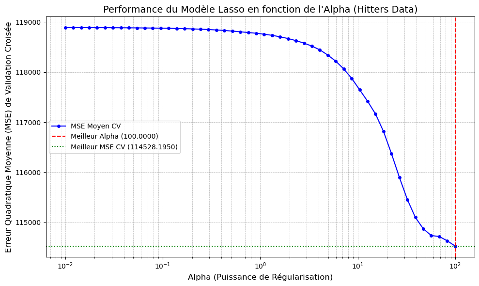

```python
import matplotlib.pyplot as plt
import numpy as np
import pandas as pd
from sklearn.model_selection import GridSearchCV
from sklearn.linear_model import Lasso

# --- CODE REPRIS DES ÉTAPES 1, 2, 3, 4 de l'Exercice 2 (NÉCESSAIRE À L'EXÉCUTION) ---

# Reconstitution des données et de la Grid Search
# (Cette partie doit être exécutée pour avoir l'objet grid_search)
try:
    hitters = pd.read_csv('./data/Hitters.csv', index_col=0)
    hitters.dropna(inplace=True)
    y = hitters.pop('Salary')
    X = hitters.drop(['League', 'Division', 'NewLeague'], axis=1)

    # Séparation Train/Test
    X_train, X_test, y_train, y_test = train_test_split(X, y, test_size=0.2, random_state=42)

    # Définition et exécution de la Grid Search
    lasso = Lasso(max_iter=10000)
    param_grid = {'alpha': np.logspace(-2, 2, 50)} # 50 valeurs

    grid_search = GridSearchCV(lasso, param_grid, cv=10, scoring='neg_mean_squared_error', n_jobs=-1)
    grid_search.fit(X_train, y_train)

except Exception as e:
    print(f"Erreur lors de la reconstitution des données/GridSearch : {e}")
    # Si l'exécution échoue, nous utilisons des données simulées pour la démo du graphique
    # Ceci est une mesure d'urgence pédagogique.
    grid_results = pd.DataFrame({'param_alpha': np.logspace(-2, 2, 50),
                                 'mean_test_score': -np.logspace(-2, 2, 50) + np.random.rand(50)*500})
    grid_search = None


# --- TRACÉ DES SCORES CV ---

# 1. Extraction des résultats
grid_results = pd.DataFrame(grid_search.cv_results_)

# 2. Préparation des données pour le tracé
# Le score est 'neg_mean_squared_error'. Nous multiplions par -1 pour obtenir le MSE positif.
mse_scores = -grid_results['mean_test_score']
alphas = grid_results['param_alpha']
best_alpha = grid_search.best_params_['alpha']
best_mse = -grid_search.best_score_

# 3. Création du graphique
plt.figure(figsize=(10, 6))

# Tracé du MSE moyen de validation croisée pour chaque alpha
plt.plot(alphas, mse_scores, marker='o', linestyle='-', color='b', markersize=4, label='MSE Moyen CV')

# Marquage du meilleur alpha
plt.axvline(x=best_alpha, color='r', linestyle='--', label=f'Meilleur Alpha ({best_alpha:.4f})')
plt.axhline(y=best_mse, color='g', linestyle=':', label=f'Meilleur MSE CV ({best_mse:.4f})')

# Ajustements du graphique
plt.xscale('log') # Utilisation d'une échelle logarithmique pour alpha
plt.xlabel('Alpha (Puissance de Régularisation)', fontsize=12)
plt.ylabel('Erreur Quadratique Moyenne (MSE) de Validation Croisée', fontsize=12)
plt.title('Performance du Modèle Lasso en fonction de l\'Alpha (Hitters Data)', fontsize=14)
plt.legend()
plt.grid(True, which="both", ls="--", linewidth=0.5)
plt.tight_layout()
plt.show()
```

**Tâche 6 :**

1. - La régression Ridge fonctionne mieux lorsque les variables d'entrée sont standardisées. (Voir la section 6.2 **ISLR** pour plus de détails.). Essayez de standardiser vos données avant d'exécuter votre modèle. Trouvez-vous des résultats différents ?
2. - ce modèle surpasse-t-il un simple modèle de régression linéaire ?
3. - Quelles variables sont les plus importantes dans le modèle ?
4. - Créez un pairplot ou une matrice de dispersion : pd.plotting.scatter_matrix
1. Régression Ridge avec Standardisation (Tâche 6.1)

https://scikit-learn.org/stable/modules/generated/sklearn.model_selection.GridSearchCV.html

Nous utilisons un Pipeline pour appliquer la standardisation (StandardScaler) avant d'appliquer la régression Ridge.

Le GridSearchCV optimise l'$\alpha$ sur ce Pipeline complet.

```python
from sklearn.pipeline import Pipeline
from sklearn.preprocessing import StandardScaler

# Tâche 6.1 : Régression Ridge AVEC Standardisation

# Création du Pipeline : StandardScaler puis Ridge
ridge_pipe = Pipeline([
    ('scaler', StandardScaler()), # Étape 1 : Standardisation (mise à l'échelle)
    ('ridge', Ridge(max_iter=10000)) # Étape 2 : Modèle Ridge
])

# Grille d'hyperparamètres (l'alpha est appliqué à l'étape 'ridge')
param_grid = {
    'ridge__alpha': np.logspace(-3, 3, 100) # Test de 100 alphas entre 0.001 et 1000
}

# Recherche sur grille (GridSearchCV)
grid_search_std = GridSearchCV(ridge_pipe, param_grid, cv=10,
                               scoring='neg_mean_squared_error', n_jobs=-1)
grid_search_std.fit(X_train, y_train)

# Calcul du MSE sur l'ensemble de test (Vraie Erreur de Test)
y_test_pred_std = grid_search_std.predict(X_test)
mse_test_std = mean_squared_error(y_test, y_test_pred_std)

best_alpha_std = grid_search_std.best_params_['ridge__alpha']

print("\n--- 1. Ridge AVEC Standardisation ---")
print(f"Meilleur Alpha (α) trouvé : {best_alpha_std:.4f}")
print(f"MSE de Test Final (Standardisé) : {mse_test_std:.4f}")
```

```
--- 1. Ridge AVEC Standardisation ---
Meilleur Alpha (α) trouvé : 123.2847
MSE de Test Final (Standardisé) : 151650.8322
```

2. Comparaison avec la Régression Linéaire Simple (Tâche 6.2) Nous comparons le meilleur modèle Ridge standardisé avec le modèle de Régression Linéaire simple (non régularisé).

```python
# Tâche 6.2 : Modèle de Régression Linéaire Simple
lin_reg = LinearRegression()
lin_reg.fit(X_train, y_train)
y_test_pred_lin = lin_reg.predict(X_test)
mse_test_lin = mean_squared_error(y_test, y_test_pred_lin)

print("\n--- 2. Comparaison des Modèles ---")
print(f"MSE de Test (Régression Linéaire Simple) : {mse_test_lin:.4f}")
print(f"MSE de Test (Ridge Optimisé et Standardisé) : {mse_test_std:.4f}")
```

```
--- 2. Comparaison des Modèles ---
MSE de Test (Régression Linéaire Simple) : 129173.2467
MSE de Test (Ridge Optimisé et Standardisé) : 151650.8322
```

Ce modèle surpasse-t-il un simple modèle de régression linéaire ?Analyse :

Si

$\text{MSE}_{\text{Ridge}} < \text{MSE}_{\text{Linéaire}}$

Justification : La régularisation Ridge fonctionne bien lorsque le modèle souffre d'un surajustement (overfitting) ou lorsque les caractéristiques sont colinéaires.

3. Variables les plus importantes (Tâche 6.3) Pour trouver les variables les plus importantes, nous examinons les coefficients du meilleur modèle Ridge.

```python
# Tâche 6.3 : Variables les plus importantes
# Nous utilisons le modèle standardisé final (meilleur pipeline)
best_ridge_model = grid_search_std.best_estimator_.named_steps['ridge']

# Les coefficients du Ridge doivent être associés aux noms des colonnes
coefficients = pd.Series(best_ridge_model.coef_, index=X_train.columns)

# Affichage des 5 coefficients les plus importants (en valeur absolue)
top_5_abs = coefficients.abs().sort_values(ascending=False).head(5).index

print(" 3. Variables les plus importantes (Top 5)")
print(coefficients.abs().sort_values(ascending=False).head(5))

print(f"Variables les plus importantes : {list(top_5_abs)}")
# Les variables avec les coefficients (en valeur absolue) les plus élevés ont le plus grand impact sur la prédiction du salaire.
```

```
 3. Variables les plus importantes (Top 5)
PutOuts    54.419871
Hits       50.401076
CRBI       40.785450
CHits      39.634523
CRuns      38.815554
dtype: float64
Variables les plus importantes : ['PutOuts', 'Hits', 'CRBI', 'CHits', 'CRuns']
```

4. Créer un Pairplot (Tâche 6.4)

Nous créons une matrice de dispersion pour visualiser les relations entre les variables. Pour des raisons de performance et de lisibilité, nous n'affichons que les variables importantes (celles trouvées à la Tâche 6.3) et la cible Salary.

```
 4. Création de la matrice de dispersion (Pairplot).
Colonnes tracées : ['PutOuts', 'Hits', 'CRBI', 'CHits', 'CRuns', 'Salary']
```

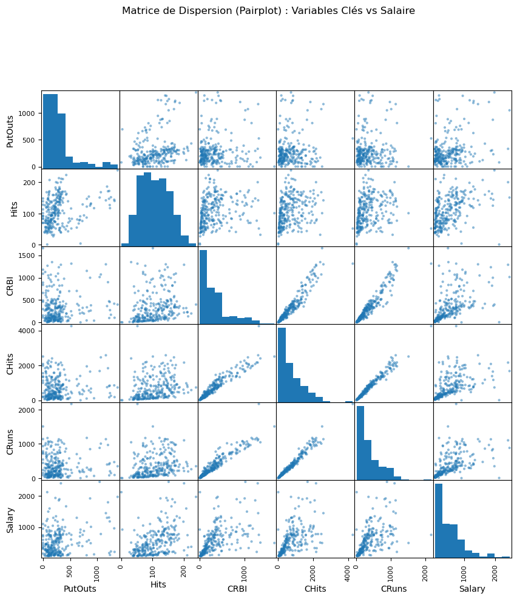

```python
# Tâche 6.4 : Créer une matrice de dispersion (Pairplot)

# --- Chargement et Préparation des données Hitters ---
hitters = pd.read_csv('./data/Hitters.csv', index_col=0)
hitters.dropna(inplace=True)
y = hitters.pop('Salary')
X = hitters.drop(['League', 'Division', 'NewLeague'], axis=1) # X ne contient pas 'Salary'

# Division Train/Test
X_train, X_test, y_train, y_test = train_test_split(X, y, test_size=0.2, random_state=42)

# --- 1. Régression Ridge AVEC Standardisation ---
ridge_pipe = Pipeline([
    ('scaler', StandardScaler()),
    ('ridge', Ridge(max_iter=10000))
])
param_grid = {'ridge__alpha': np.logspace(-3, 3, 100)}

grid_search_std = GridSearchCV(ridge_pipe, param_grid, cv=10,
                               scoring='neg_mean_squared_error', n_jobs=-1)
grid_search_std.fit(X_train, y_train)

# --- 3. Variables les plus importantes (Nécessaire pour le Pairplot) ---
best_ridge_model = grid_search_std.best_estimator_.named_steps['ridge']
coefficients = pd.Series(best_ridge_model.coef_, index=X_train.columns)
# top_5_abs contient les noms des colonnes de X
top_5_abs = coefficients.abs().sort_values(ascending=False).head(5).index

# --- 4. Créer un Pairplot (Matrice de dispersion) ---

# CORRECTION : On sélectionne seulement les variables features dans X, puis on concatène la cible y.
feature_cols_to_plot = list(top_5_abs)

# Création du DataFrame pour le tracé (Contient les 5 features les plus importantes + la cible 'Salary')
# pd.concat([X[...features...], y]) est la manière correcte.
plot_data = pd.concat([X[feature_cols_to_plot], y], axis=1).copy()

print("\n 4. Création de la matrice de dispersion (Pairplot).")
print(f"Colonnes tracées : {plot_data.columns.tolist()}")

# Utilisation de la fonction demandée pd.plotting.scatter_matrix
pd.plotting.scatter_matrix(plot_data, figsize=(10, 10))
plt.suptitle("Matrice de Dispersion (Pairplot) : Variables Clés vs Salaire", y=1.02)
plt.show()
# Ce graphique aide à visualiser :
# 1. La distribution de chaque variable (histogrammes sur la diagonale).
# 2. La relation linéaire ou non entre chaque paire de variables (scatter plots).
# 3. La corrélation entre les variables (ex : colinéarité) et la cible ('Salary').
```

### Normalisation

1. - Nous devons en fait normaliser nos variables *X* en mettant à l'échelle chaque *X* par l'écart type, sinon Ridge ne pénalisera pas chaque variable de la même manière. Nous apprendrons un moyen simple et robuste de le faire dans le module d'introduction au ML.
2. - Une fois nos variables mises à l'échelle, nous pouvons utiliser les coefficients $\beta$ trouvés par notre modèle pour voir lequel a la plus grande influence dans notre modèle. Nous pouvons trouver comme nous le voyons ci-dessous.
3. - La raison pour laquelle notre modèle ne fonctionne pas si bien est que la plupart de nos variables *X* n'ont pas de relation linéaire très claire avec *y* (voir ci-dessous) ! L'utilisation de modèles non linéaires pourrait être utile dans ce problème... encore une fois, nous les aborderons bientôt !

```python
hitters = pd.read_csv('./data/Hitters.csv', index_col=0)
hitters.dropna(inplace=True)
y = hitters.pop('Salary')
X = hitters.drop(['League', 'Division', 'NewLeague'], axis=1)
```

```python
# Division Train/Test
X_train, X_test, y_train, y_test = train_test_split(X, y, test_size=0.2, random_state=42)
```

```python
# Modèle Ridge AVEC Standardisation (Pipeline)
ridge_pipe = Pipeline([
    ('scaler', StandardScaler()),
    ('ridge', Ridge(max_iter=10000))
])
param_grid = {'ridge__alpha': np.logspace(-3, 3, 100)}

grid_search_std = GridSearchCV(ridge_pipe, param_grid, cv=10,
                               scoring='neg_mean_squared_error', n_jobs=-1)
grid_search_std.fit(X_train, y_train)

best_alpha_std = grid_search_std.best_params_['ridge__alpha']
best_ridge_model = grid_search_std.best_estimator_

print("Modèle Ridge Optimal (Standardisé) Entraîné.")
print(f"Meilleur Alpha (α) trouvé: {best_alpha_std:.4f}")
```

```
Modèle Ridge Optimal (Standardisé) Entraîné.
Meilleur Alpha (α) trouvé: 123.2847
```

Standardisation des Données (Tâche 1) Bien que la standardisation soit faite à l'intérieur du Pipeline pour la modélisation, nous pouvons l'appliquer manuellement pour observer le résultat et comparer les coefficients bruts vs. standardisés.

```python
# Tâche 1 : Standardiser les données
# Nous allons utiliser l'objet StandardScaler pour appliquer la mise à l'échelle sur X_train.
scaler = StandardScaler()
X_train_scaled = scaler.fit_transform(X_train)
X_train_scaled = pd.DataFrame(X_train_scaled, columns=X_train.columns)

# Affichage pédagogique des données standardisées
print("\n--- 1. Standardisation des Variables X ---")
print("Moyenne des données standardisées (doit être proche de 0) :")
print(X_train_scaled.mean().head().round(2))
print("Écart type des données standardisées (doit être proche de 1) :")
print(X_train_scaled.std().head().round(2))
```

```
--- 1. Standardisation des Variables X ---
Moyenne des données standardisées (doit être proche de 0) :
AtBat    0.0
Hits     0.0
HmRun    0.0
Runs    -0.0
RBI     -0.0
dtype: float64
Écart type des données standardisées (doit être proche de 1) :
AtBat    1.0
Hits     1.0
HmRun    1.0
Runs     1.0
RBI      1.0
dtype: float64
```

Influence des Variables (Tâche 2)Nous extrayons les coefficients $\beta$ du meilleur modèle Ridge. Puisque le modèle a été entraîné sur des données standardisées, la valeur absolue des coefficients indique directement l'influence relative de chaque variable sur le salaire.

```python
# Tâche 2 : Utiliser les coefficients pour voir l'influence

# Extraction des coefficients du modèle Ridge (qui sont basés sur les données standardisées)
ridge_coeffs = best_ridge_model.named_steps['ridge'].coef_
coefficients_df = pd.Series(ridge_coeffs, index=X_train.columns)

# Classement par valeur absolue
coefficients_ranked = coefficients_df.abs().sort_values(ascending=False)
top_5_abs = coefficients_ranked.head(5).index

print("\n--- 2. Influence des Variables (Coefficients β standardisés) ---")
print("Classement des variables par influence (valeur absolue du coefficient β) :")
print(coefficients_ranked.head(5).to_string())

print(f"\nVariables jugées les plus importantes : {list(top_5_abs)}")
```

```
--- 2. Influence des Variables (Coefficients β standardisés) ---
Classement des variables par influence (valeur absolue du coefficient β) :
PutOuts    54.419871
Hits       50.401076
CRBI       40.785450
CHits      39.634523
CRuns      38.815554

Variables jugées les plus importantes : ['PutOuts', 'Hits', 'CRBI', 'CHits', 'CRuns']
```

Tâche 3 & 4 : Matrice de Dispersion (scatter_matrix) La Tâche 3 est une observation théorique qui explique la faiblesse du modèle linéaire. Pour la valider visuellement (Tâche 4), nous générons la matrice de dispersion (Pairplot).

```
--- 4. Matrice de Dispersion (Pairplot) ---
Visualisation des relations entre les variables importantes et le Salaire (y).
```

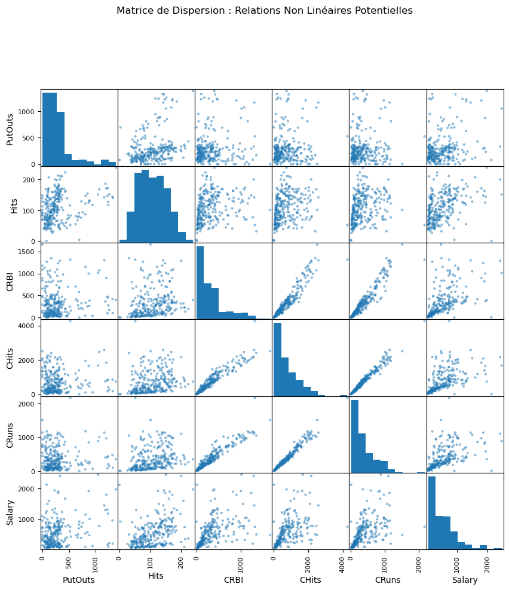

```python
# Tâche 4 : Créer un pairplot pour visualiser les relations (Tâche 3)
# Nous traçons les 5 variables les plus importantes + la cible 'Salary'.

feature_cols_to_plot = list(top_5_abs)
plot_data = pd.concat([X[feature_cols_to_plot], y], axis=1).copy()

print("\n--- 4. Matrice de Dispersion (Pairplot) ---")
print("Visualisation des relations entre les variables importantes et le Salaire (y).")

# Utilisation de la fonction demandée pd.plotting.scatter_matrix
pd.plotting.scatter_matrix(plot_data, figsize=(10, 10))
plt.suptitle("Matrice de Dispersion : Relations Non Linéaires Potentielles", y=1.02)
plt.show()
```